# Exercise III

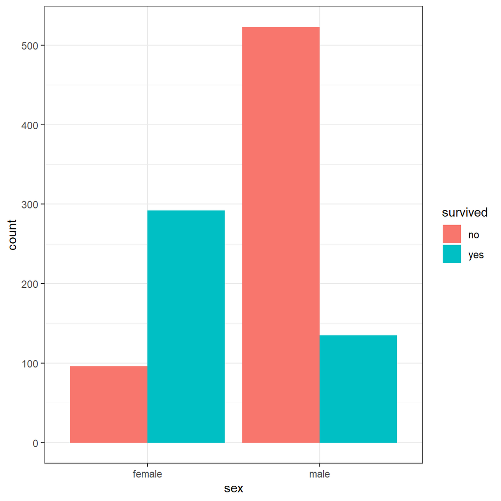

```r
ggplot(Titanic)+
  geom_bar(aes(x = sex, fill = survived), position = 'dodge')+
  geom_bar(aes(x = sex, fill = survived), position = 'dodge')
```

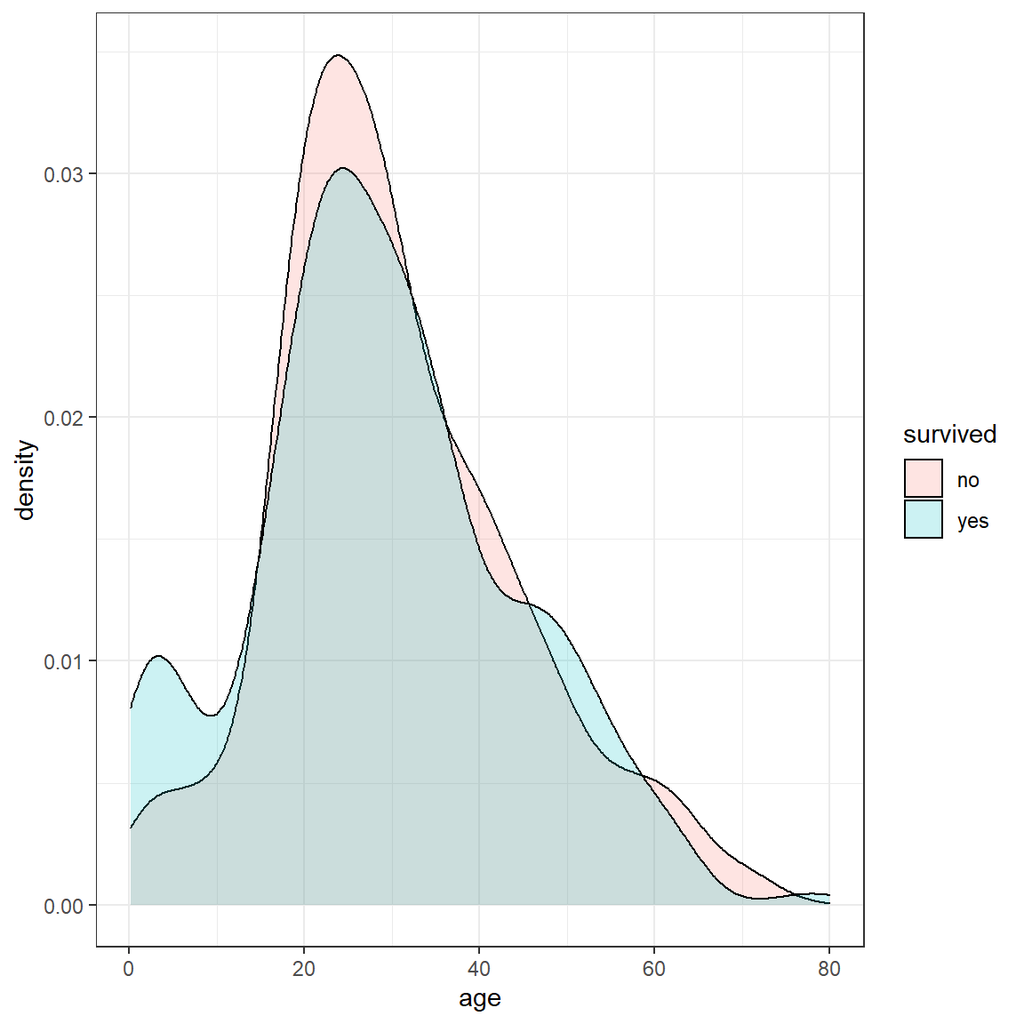

```r
ggplot(data = Titanic, aes(x = age, fill = survived)) +
  geom_density(alpha = 0.2)
```

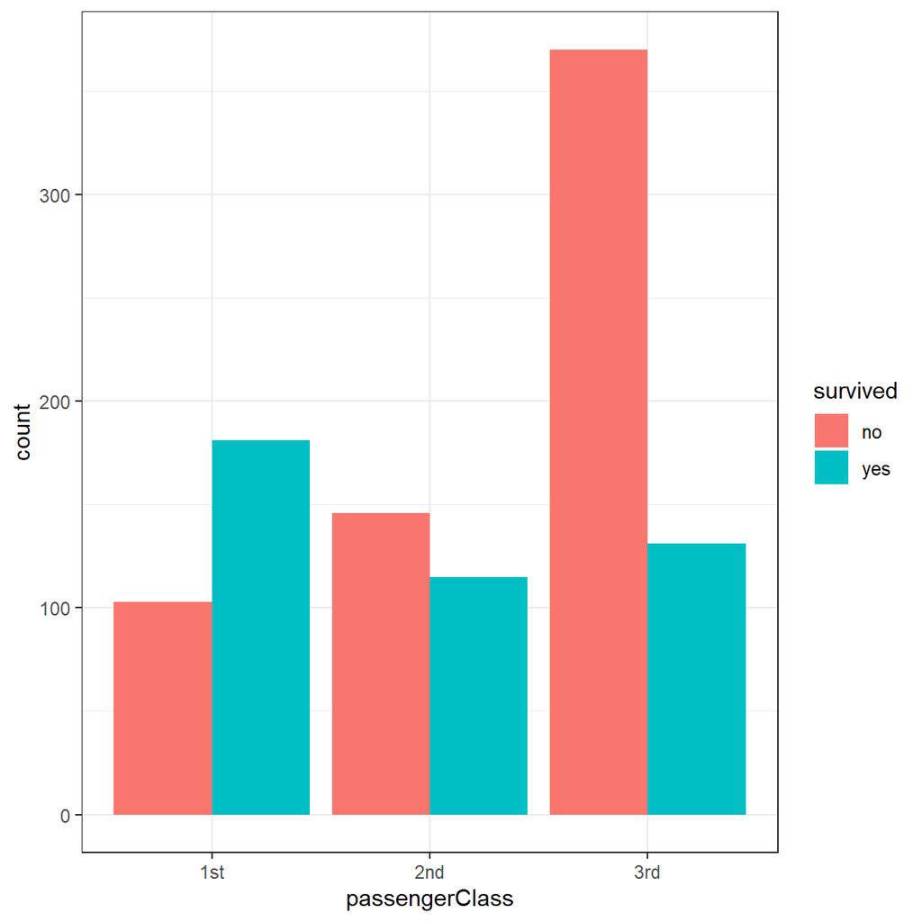

```r
ggplot(Titanic)+
  geom_bar(aes(x = passengerClass, fill = survived), position = 'dodge')+
  geom_bar(aes(x = passengerClass, fill = survived), position = 'dodge')
```

```r
table(Titanic$passengerClass, Titanic$sex, Titanic$survived)
```

```
, ,  = no


      female male
  1st      5   98
  2nd     11  135
  3rd     80  290

, ,  = yes


      female male
  1st    128   53
  2nd     92   23
  3rd     72   59
```

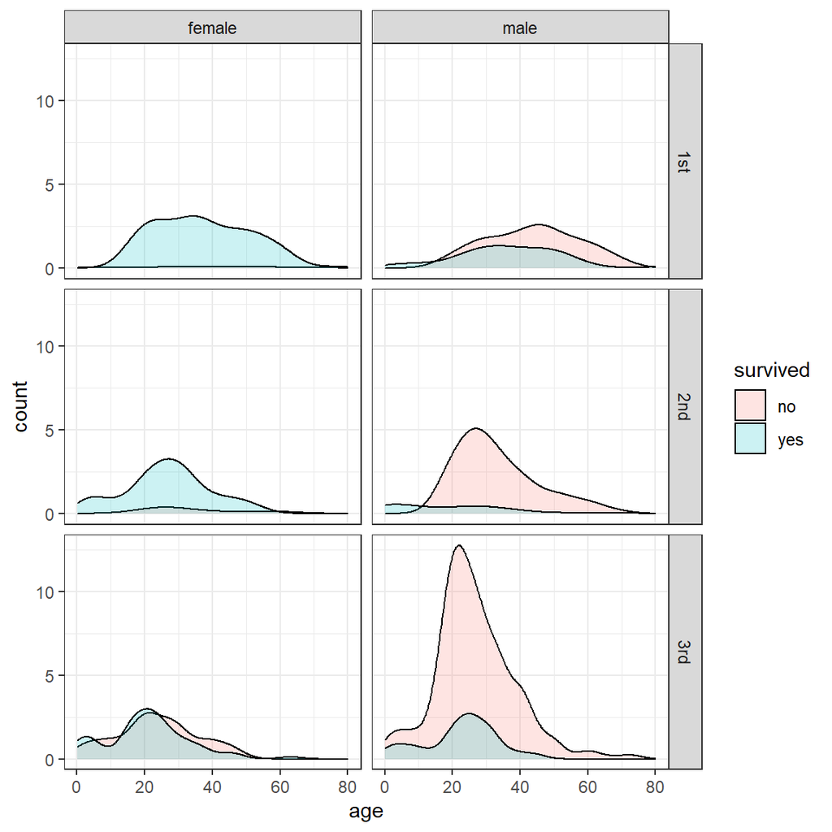

```r
ggplot(data = Titanic, aes(x = age, y = ..count.., fill = survived)) +
  geom_density(alpha = 0.2) +
  facet_grid(passengerClass ~ sex)
```

From visualization we can suggest that female from 1st class is most likely to survive. But now let’s build a proper logistic regression model

```r
model <- glm(survivedYes ~ class + sexFemale + age, data = Titanic, family = binomial)
summary(model)
```

```
Call:
glm(formula = survivedYes ~ class + sexFemale + age, family = binomial,
    data = Titanic)

Deviance Residuals:
    Min       1Q   Median       3Q      Max
-2.6159  -0.7162  -0.4321   0.6572   2.4041

Coefficients:
            Estimate Std. Error z value Pr(>|z|)
(Intercept)  2.09189    0.37138   5.633 1.77e-08 ***
class       -1.13324    0.11173 -10.143  < 2e-16 ***
sexFemale    2.49738    0.16612  15.034  < 2e-16 ***
age         -0.03388    0.00628  -5.395 6.84e-08 ***
---
Signif. codes:  0 '***' 0.001 '**' 0.01 '*' 0.05 '.' 0.1 ' ' 1

(Dispersion parameter for binomial family taken to be 1)

    Null deviance: 1414.62  on 1045  degrees of freedom
Residual deviance:  983.02  on 1042  degrees of freedom
AIC: 991.02

Number of Fisher Scoring iterations: 4
```

The higher class and age the less chances to survive (significant negative coefficients). However, females are more likely to survive (significant positive coefficient).

```r
model2 <- update(model, ~ sexFemale * class)
summary(model2)
```

```
Call:
glm(formula = survivedYes ~ sexFemale + class + sexFemale:class,
    family = binomial, data = Titanic)

Deviance Residuals:
    Min       1Q   Median       3Q      Max
-2.7229  -0.7076  -0.5740   0.5502   1.9415

Coefficients:
                Estimate Std. Error z value Pr(>|z|)
(Intercept)      -0.3312     0.2624  -1.262    0.207
sexFemale         5.8843     0.6820   8.628  < 2e-16 ***
class            -0.4629     0.1149  -4.031 5.56e-05 ***
sexFemale:class  -1.4080     0.2589  -5.439 5.35e-08 ***
---
Signif. codes:  0 '***' 0.001 '**' 0.01 '*' 0.05 '.' 0.1 ' ' 1

(Dispersion parameter for binomial family taken to be 1)

    Null deviance: 1414.62  on 1045  degrees of freedom
Residual deviance:  976.52  on 1042  degrees of freedom
AIC: 984.52

Number of Fisher Scoring iterations: 5
```

Interaction between sex and class is significant

```r
model3 <- update(model, ~ age * class)
summary(model3)
```

```
Call:
glm(formula = survivedYes ~ age + class + age:class, family = binomial,
    data = Titanic)

Deviance Residuals:
    Min       1Q   Median       3Q      Max
-2.0018  -0.9048  -0.6572   1.0689   2.3188

Coefficients:
             Estimate Std. Error z value Pr(>|z|)
(Intercept)  2.956686   0.516565   5.724 1.04e-08 ***
age         -0.032353   0.013001  -2.488   0.0128 *
class       -1.028381   0.208920  -4.922 8.55e-07 ***
age:class   -0.002389   0.006090  -0.392   0.6949
---
Signif. codes:  0 '***' 0.001 '**' 0.01 '*' 0.05 '.' 0.1 ' ' 1

(Dispersion parameter for binomial family taken to be 1)

    Null deviance: 1414.6  on 1045  degrees of freedom
Residual deviance: 1256.0  on 1042  degrees of freedom
AIC: 1264

Number of Fisher Scoring iterations: 4
```

Age:class - no interactions

```r
model4 <- update(model, ~ sexFemale * age)
summary(model4)
```

```
Call:
glm(formula = survivedYes ~ sexFemale + age + sexFemale:age,
    family = binomial, data = Titanic)

Deviance Residuals:
    Min       1Q   Median       3Q      Max
-2.0247  -0.7158  -0.5776   0.7707   2.2960

Coefficients:
               Estimate Std. Error z value Pr(>|z|)
(Intercept)   -0.660758   0.224807  -2.939 0.003290 **
sexFemale      1.154139   0.339337   3.401 0.000671 ***
age           -0.023760   0.007276  -3.266 0.001092 **
sexFemale:age  0.046276   0.011216   4.126 3.69e-05 ***
---
Signif. codes:  0 '***' 0.001 '**' 0.01 '*' 0.05 '.' 0.1 ' ' 1

(Dispersion parameter for binomial family taken to be 1)

    Null deviance: 1414.6  on 1045  degrees of freedom
Residual deviance: 1083.4  on 1042  degrees of freedom
AIC: 1091.4

Number of Fisher Scoring iterations: 4
```

sex:age - significant interactions

```r
model5 <- glm(survivedYes ~ sexFemale * (class + age), data = Titanic, family = binomial)
summary(model5)
```

```
Call:
glm(formula = survivedYes ~ sexFemale * (class + age), family = binomial,
    data = Titanic)

Deviance Residuals:
    Min       1Q   Median       3Q      Max
-2.9724  -0.6925  -0.4775   0.5214   2.3423

Coefficients:
                 Estimate Std. Error z value Pr(>|z|)
(Intercept)      1.695747   0.459053   3.694 0.000221 ***
sexFemale        4.778394   0.945366   5.055 4.31e-07 ***
class           -0.795643   0.135088  -5.890 3.87e-09 ***
age             -0.044121   0.008286  -5.324 1.01e-07 ***
sexFemale:class -1.232172   0.285314  -4.319 1.57e-05 ***
sexFemale:age    0.023628   0.013872   1.703 0.088515 .
---
Signif. codes:  0 '***' 0.001 '**' 0.01 '*' 0.05 '.' 0.1 ' ' 1

(Dispersion parameter for binomial family taken to be 1)

    Null deviance: 1414.62  on 1045  degrees of freedom
Residual deviance:  941.65  on 1040  degrees of freedom
AIC: 953.65

Number of Fisher Scoring iterations: 5
```

```r
model_em <- glm(survivedYes ~ sexFemale * (passengerClass + age), data = Titanic, family = binomial)
(emm <- emmeans(model_em, "passengerClass", by = "sexFemale"))
```

```
sexFemale = 0:
 passengerClass emmean    SE  df asymp.LCL asymp.UCL
 1st             -0.14 0.194 Inf    -0.521     0.240
 2nd             -1.87 0.235 Inf    -2.335    -1.413
 3rd             -1.88 0.160 Inf    -2.194    -1.567

sexFemale = 1:
 passengerClass emmean    SE  df asymp.LCL asymp.UCL
 1st              3.42 0.472 Inf     2.496     4.348
 2nd              2.10 0.320 Inf     1.475     2.730
 3rd             -0.26 0.186 Inf    -0.625     0.104

Results are given on the logit (not the response) scale.
Confidence level used: 0.95
```

```r
pairs(emm, reverse = TRUE)
```

```
sexFemale = 0:
 contrast  estimate    SE  df z.ratio p.value
 2nd - 1st -1.73315 0.315 Inf -5.505  <.0001
 3rd - 1st -1.73988 0.270 Inf -6.433  <.0001
 3rd - 2nd -0.00673 0.275 Inf -0.025  0.9997

sexFemale = 1:
 contrast  estimate    SE  df z.ratio p.value
 2nd - 1st -1.32025 0.570 Inf -2.315  0.0537
 3rd - 1st -3.68273 0.529 Inf -6.967  <.0001
 3rd - 2nd -2.36248 0.371 Inf -6.374  <.0001

Results are given on the log odds ratio (not the response) scale.
P value adjustment: tukey method for comparing a family of 3 estimates
```

```r
(emm2 <- emmeans(model5, c("age", "sexFemale"), at = list(age = 0:1)))
```

```
 age sexFemale  emmean    SE  df asymp.LCL asymp.UCL
   0         0 -0.0606 0.250 Inf    -0.550     0.429
   1         0 -0.1047 0.242 Inf    -0.579     0.370
   0         1  1.9978 0.364 Inf     1.284     2.711
   1         1  1.9773 0.354 Inf     1.283     2.672

Results are given on the logit (not the response) scale.
Confidence level used: 0.95
```

```r
contrast(emm2, method = list(
    age = list(
        male = c(-1, 1, 0, 0),
        female = c(0, 0, -1, 1)
    )
), type = "response")
```

```
 contrast   odds.ratio      SE  df null z.ratio p.value
 age.male        0.957 0.00793 Inf    1 -5.324  <.0001
 age.female      0.980 0.01090 Inf    1 -1.842  0.0655

Tests are performed on the log odds ratio scale
```

It seems that the age matters for males with a negative effect.

```r
emmeans(model5, c("age", "sexFemale"), at = list(age = c(18,30, 40, 60)), type = "response")
```

```
 age sexFemale   prob     SE  df asymp.LCL asymp.UCL
  18         0 0.2984 0.0268 Inf    0.2486     0.354
  30         0 0.2003 0.0165 Inf    0.1700     0.235
  40         0 0.1388 0.0172 Inf    0.1083     0.176
  60         0 0.0625 0.0168 Inf    0.0366     0.105
  18         1 0.8360 0.0287 Inf    0.7718     0.885
  30         1 0.7995 0.0275 Inf    0.7403     0.848
  40         1 0.7646 0.0379 Inf    0.6824     0.831
  60         1 0.6831 0.0835 Inf    0.5030     0.821

Confidence level used: 0.95
Intervals are back-transformed from the logit scale
```

Again, for males older age makes them less likely to survive.

```r
emmeans(model5, c("class", "sexFemale", "age"), at = list(class = c(1,2,3), age = c(18, 40, 60)), type = "response")
```

```
 class sexFemale age   prob      SE  df asymp.LCL asymp.UCL
     1         0  18 0.5265 0.05723 Inf    0.4148    0.6355
     2         0  18 0.3341 0.03058 Inf    0.2771    0.3964
     3         0  18 0.1846 0.02211 Inf    0.1451    0.2319
     1         1  18 0.9833 0.00771 Inf    0.9591    0.9933
     2         1  18 0.8859 0.02502 Inf    0.8270    0.9265
     3         1  18 0.5055 0.04150 Inf    0.4247    0.5859
     1         0  40 0.2964 0.03556 Inf    0.2317    0.3704
     2         0  40 0.1597 0.01821 Inf    0.1272    0.1987
     3         0  40 0.0790 0.01531 Inf    0.0537    0.1147
     1         1  40 0.9741 0.01022 Inf    0.9444    0.9881
     2         1  40 0.8319 0.03185 Inf    0.7600    0.8855
     3         1  40 0.3944 0.06142 Inf    0.2823    0.5187
     1         0  60 0.1484 0.03229 Inf    0.0955    0.2233
     2         0  60 0.0729 0.01859 Inf    0.0439    0.1188
     3         0  60 0.0343 0.01159 Inf    0.0176    0.0658
     1         1  60 0.9615 0.01721 Inf    0.9094    0.9841
     2         1  60 0.7666 0.06867 Inf    0.6075    0.8745
     3         1  60 0.3018 0.09544 Inf    0.1510    0.5122

Confidence level used: 0.95
Intervals are back-transformed from the logit scale
```

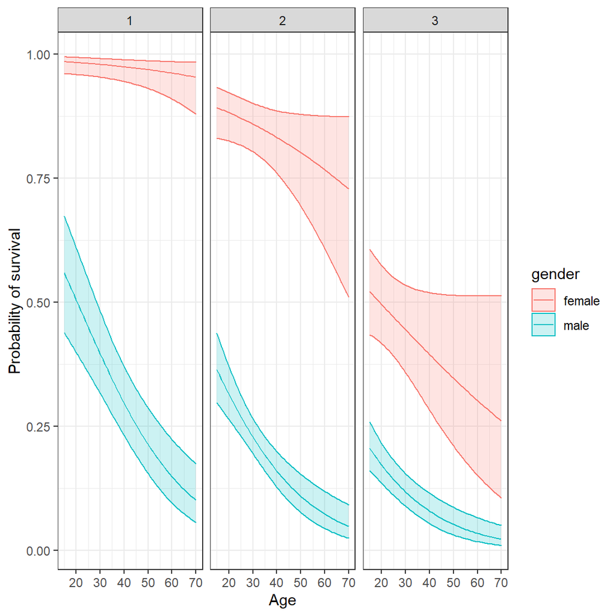

```r
emmeans(model5, c("age", "sexFemale", "class"), at = list(
    class = c(1,2,3),
    age = seq(15, 70, by = 1)
), type = "response") %>%
    tidy(conf.int = TRUE) %>%
    mutate(gender = if_else(sexFemale == 1, "female", "male")) %>%
    ggplot(aes(x = age, y = prob, color = gender, fill = gender, group = gender)) +
    geom_line() +
    geom_ribbon(aes(ymin = asymp.LCL, ymax = asymp.UCL), alpha = .2) +
    labs(x = "Age", y = "Probability of survival") +
    facet_wrap(~class)
```

```r
PseudoR2(model5, which = "Nagelkerke")
```

```
Nagelkerke
 0.4906456
```

```r
model0 <- update(model5, ~ 1)
lrtest(model5, model0)
```

```
Likelihood ratio test

Model 1: survivedYes ~ sexFemale * (class + age)
Model 2: survivedYes ~ 1
  #Df  LogLik Df  Chisq Pr(>Chisq)
1   6 -470.82
2   1 -707.31 -5 472.97  < 2.2e-16 ***
---
Signif. codes:  0 '***' 0.001 '**' 0.01 '*' 0.05 '.' 0.1 ' ' 1
```

```r
model5 %>%
    confint
```

```
                       2.5 %      97.5 %
(Intercept)      0.804281441  2.60750367
sexFemale        2.990552363  6.70953713
class           -1.064249622 -0.53378791
age             -0.060748240 -0.02821369
sexFemale:class -1.816247140 -0.69332424
sexFemale:age   -0.003658098  0.05082380
```

Report:

To study which factors were associated with survival during Titanic catastrophe, a logistic regression model was fitted. The response variable (survived) was a dichotomous indicator of whether a given person survived or not. The predictors were age (in years), sex (male, female) and class (1st, 2nd, 3rd). The model included also an interaction effects in order to study possible age and class effects for each gender.

sexFemale: 4.77839441 (95% CI = [2.990552363, 6.70953713], p-value < 0.05)

class: -0.79564251 (95% CI = [-1.064249622, -0.53378791], p-value < 0.05)

age: -0.04412058 (95% CI = [-0.060748240, -0.02821369], p-value < 0.05)

sexFemale:class: -1.23217243 (95% CI = [-1.816247140, -0.69332424], p-value < 0.05)

sexFemale:age: 0.02362814 (95% CI = [-0.003658098, 0.05082380], p-value = 0.088515)

Effect of sexFemale was significantly positive, indicating that females have better chance of survival. Effects of class and age were significantly negative, which means that the older people and the higher class, the less likely it is to survive. However, there was also significant interaction of sex class. In order to study closely interaction effect of sex and age, a test of contrast has been conducted. The result was that for females age is not significant, but for males it has significantly negative impact.

# Extra problems

Below are two extra problems. They are not really much harder, but will require some not completely trivial calculations with logarithms (but nothing too hard, really).

**NOTE.**

The two extra problems below combine some coding and pen-and-paper tasks. Code should be written here (or as a separate `.R` file) and derivations may be also written within the notebook or on a separate sheet of paper or something like that. The only requirement is to name them properly so I know which files are related to the same problem.

## PE1 (3 points)

In this problem we will use `SLID` dataset from `carData` package again. The goal is to conduct a simple $t$ test for two independent groups with `wages` being the dependent variable and `sex` the grouping variable. The thing is, you are supposed to run the $t$ test for log-transformed wages (since the distribution is right-skewed and bounded from below by zero) and then correctly interpret the results in the original scale.

In order to do so, first note the following fact. Arithmetic average over log-transformed values is:

$$\bar{x}_{\text{log}} = \frac{1}{n}\sum_{i=1}^n \log{x_i}$$
And to understand the results on the original scale the first step is to understand what $\bar{x}_{\text{log}}$ is on the original scale. That is, derive:

$$\bar{x} = e^{\bar{x}_{\text{log}}}$$

**HINT.** The result you will get will be so-called **geometric mean**.

$$\bar{x} = e^{\bar{x}_{\text{log}}}
\\\bar{x} = e^{\frac{1}{n}\sum_{i=1}^n \log{x_i}}
\\\bar{x} = (e^{\frac{1}{n}})^{log{x_1} + ... + log{x_n}}
\\\bar{x} = e^{{log{x_1^\frac{1}{n}}}} *...*e^{log{x_n^\frac{1}{n}}}
\\\bar{x} = (x_1*...*x_n)^{\frac{1}{n}}
\\\bar{x} = \sqrt[n]{x_1*...*x_n}$$

Then, note that the value your $t$ test is concerned with is:

$$\bar{d}_{\text{log}} = \frac{1}{n_1}\sum_{i=1}^{n_1} \log{x_i} - \frac{1}{n_2}\sum_{j=1}^{n_2} \log{x_j}$$

where $n_1$ is the size of the first group, $n_2$ is the size of the second group and indexes $i$ and $j$ iterate over elements of the first and second group respectively.

So in order to understand what the result of a $t$ test with log-transformed dependent variable means in the original scale we have to understand what is $\bar{d}$ in the original scale:

$$\bar{d} = e^{\bar{d}_{\text{log}}}$$

$$\bar{x} = e^{\bar{x}_{\text{log}}}
\\\sqrt[n]{x_1*...*x_n} = e^{\bar{x}_{\text{log}}}
\\\log{\sqrt[n]{x_1*...*x_n}} = \bar{x}_{\text{log}}$$

$$\bar{d} = e^{\bar{d}_{\text{log}}}
\\\bar{d} = \frac{e^{\bar{x_i}_{\text{log}}}}{e^{\bar{x_j}_{\text{log}}}}
\\\bar{d} = \frac{e^{\log{\sqrt[n_1]{x_1*...*x_i}}}}{e^{\log{\sqrt[n2]{x_1*...*x_j}}}}
\\\bar{d} = \frac{\sqrt[n_1]{x_1*...*x_i}}{\sqrt[n2]{x_1*...*x_j}}$$

With these results in hand you should be able to run a test with `log(wages)` as the dependent variable and interpret the results on the original scale. In particular, you should construct a proper confidence interval in the original scale.

```r
data(SLID)
(SLID <- tibble(SLID))
```

```
# A tibble: 7,425 x 5
   wages education   age sex    language
   <dbl>     <dbl> <int> <fct>  <fct>
 1  10.6      15      40 Male   English
 2  11        13.2    19 Male   English
 3  NA        16      49 Male   Other
 4  17.8      14      46 Male   Other
 5  NA         8      71 Male   English
 6  14        16      50 Female English
 7  NA        12      70 Female English
 8  NA        14.5    42 Female English
 9   8.2      15      31 Male   English
10  NA        10      56 Female English
# ... with 7,415 more rows
```

```r
SLID <- SLID[complete.cases(SLID),]
```

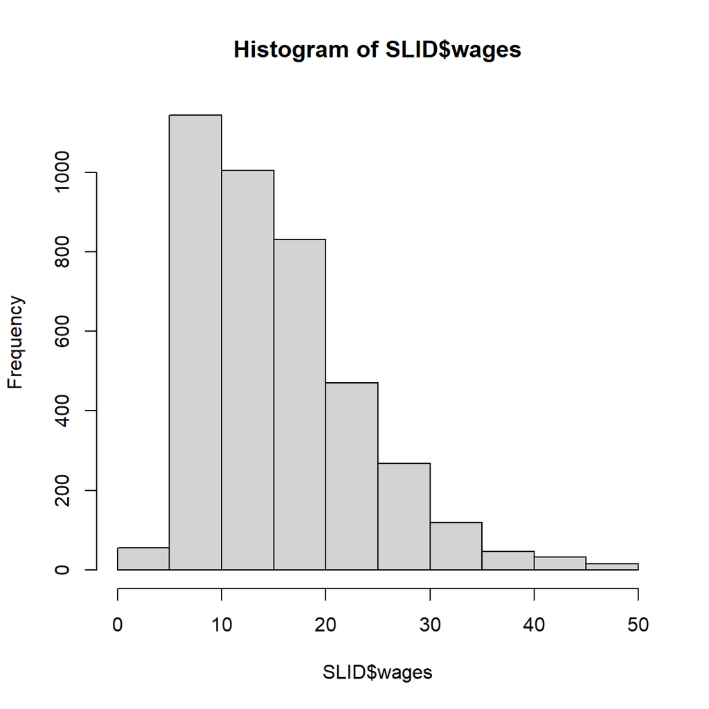

```r
hist(SLID$wages)
```

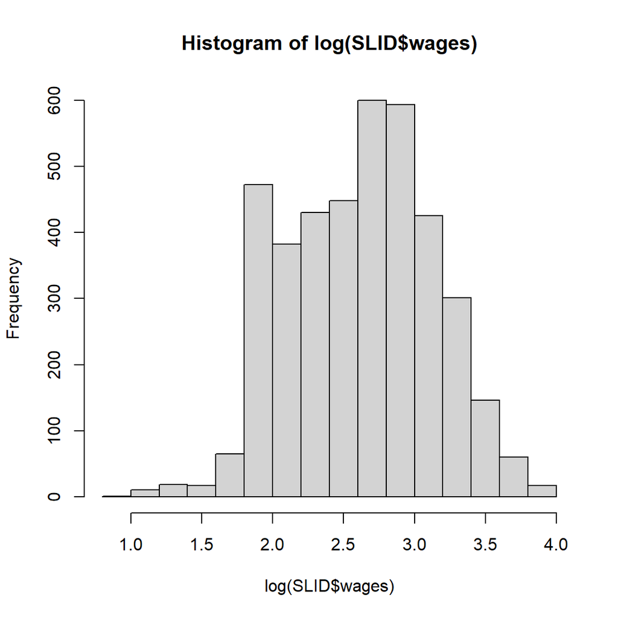

```r
hist(log(SLID$wages))
```

```r
skewness(log(SLID$wages))
```

```
[1] -0.06082738
```

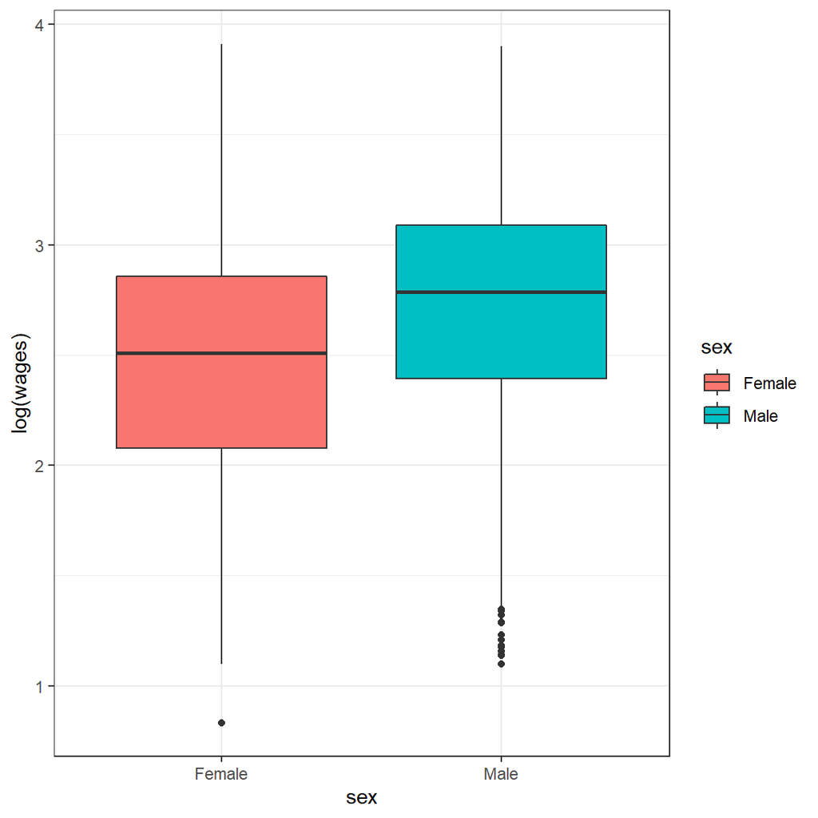

```r
ggplot(SLID, aes(x=sex, y=log(wages), fill=sex)) +
    geom_boxplot()
```

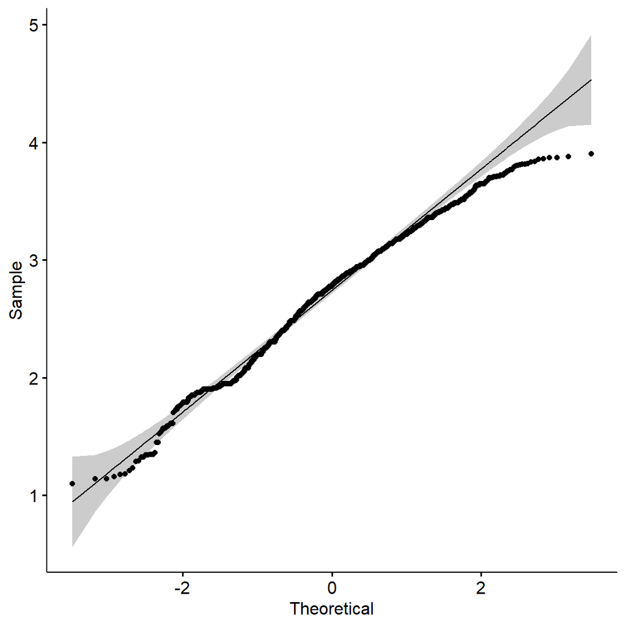

```r
ggqqplot(log(SLID$wages)[SLID$sex == "Male"])
```

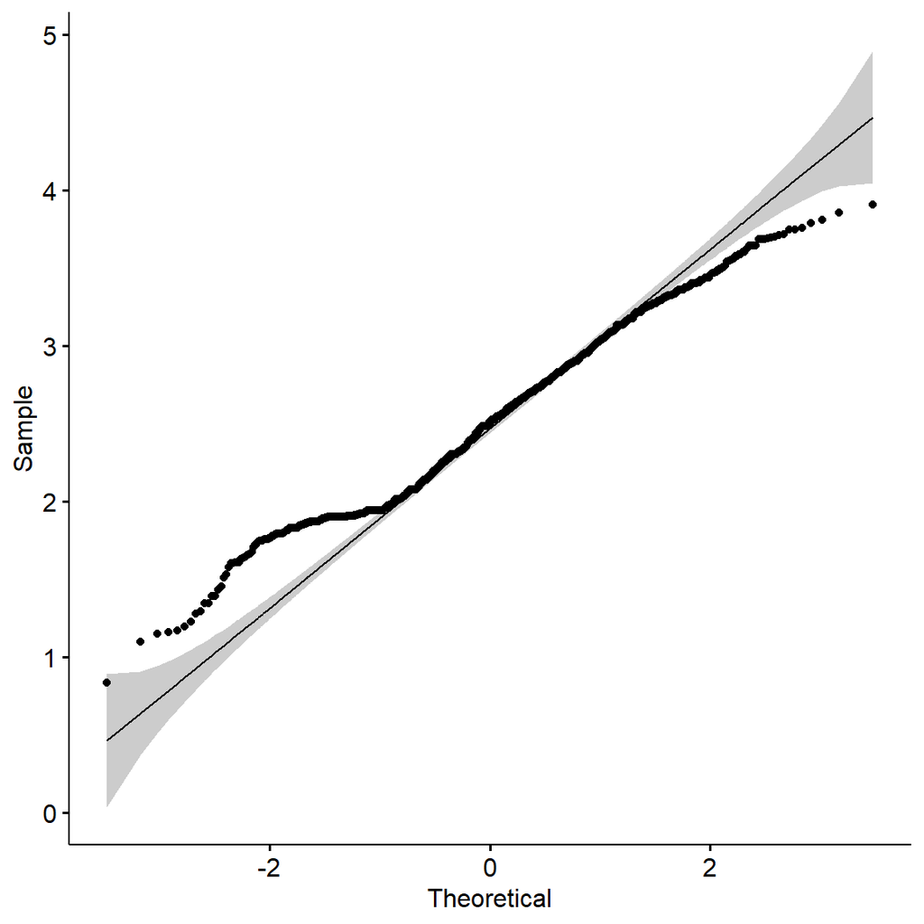

```r
ggqqplot(log(SLID$wages)[SLID$sex == "Female"])
```

```r
var.test(log(wages) ~ sex, data = SLID)
```

```
    F test to compare two variances

data:  log(wages) by sex
F = 0.9424, num df = 2000, denom df = 1985, p-value = 0.1855
alternative hypothesis: true ratio of variances is not equal to 1
95 percent confidence interval:
 0.8631394 1.0289168
sample estimates:
ratio of variances
         0.9423968
```

Distribution is pretty much normal, variances are equal.

```r
res <- t.test(log(wages) ~ sex, data = SLID, var.equal = TRUE)
res
```

```
    Two Sample t-test

data:  log(wages) by sex
t = -14.238, df = 3985, p-value < 2.2e-16
alternative hypothesis: true difference in means is not equal to 0
95 percent confidence interval:
 -0.2519799 -0.1909835
sample estimates:
mean in group Female   mean in group Male
            2.509052             2.730534
```

```r
res$estimate
```

```
mean in group Female   mean in group Male
            2.509052             2.730534
```

There is significant difference in wages for males and females.

```r
geo_male <- exp(mean(log(SLID$wages[SLID$sex == "Male"])))
geo_fe <- exp(mean(log(SLID$wages[SLID$sex == "Female"])))
geo_fe/geo_male
```

```
[1] 0.8013306
```

```r
log(geo_fe)-log(geo_male)
```

```
[1] -0.2214817
```

Report: